# Simulated Causal Analysis of PFAS Effects on Infant Neurodevelopment via Placental Imprinting

Sean T. Bresnahan

2025-07-25

# Introduction

Here I present a causal mediation framework in which maternal PFAS exposure influences infant neurodevelopment (SRS scores) via changes in placental parent-of-origin isoform expression. The mediation pathway is moderated by fetal sex, and maternal DNA methylation is leveraged as a negative control to adjust for shared genetic and environmental confounding. I compare three methods: Control Outcome Calibration (COCA), Proximal g-Computation (PGC), and regression adjustment models that include the control outcome variable as a covariate as recommended by Huang (2021).

#### Dataset:

- 100 infants
- 1000 PFAS-responsive isoforms expressed in placenta (each with 1–5 CpG sites)
- Maternal PFAS exposure
- Fetal sex
- Latent shared confounder (correlated with PFAS)
- Placental isoform-level maternal expression ratios (simulating imprinting)
- Infant SRS scores (influenced by disrupted imprinting and confounder)
- PFAS affects imprinting of a subset of isoforms
- Some imprinting-SRS associations are confounded by maternal methylation

# Load Packages and Define Knitr Options

```r
library(dplyr)
library(tidyr)
library(lavaan)
library(boot)
library(ggplot2)
library(knitr)
library(doParallel)
library(foreach)
```

# Simulate Dataset

We first define the number of samples (infants) and isoforms to be simulated.

## Define Samples and Isoforms

```r
set.seed(42)
n_samples <- 100
n_isoforms <- 1000
simulation_scenario <- "null"
```

Here we simulate fetal sex, maternal PFAS exposure levels, and a latent confounder that is correlated with PFAS.

## Generate Fetal Sex, PFAS Exposure, and Shared Confounder

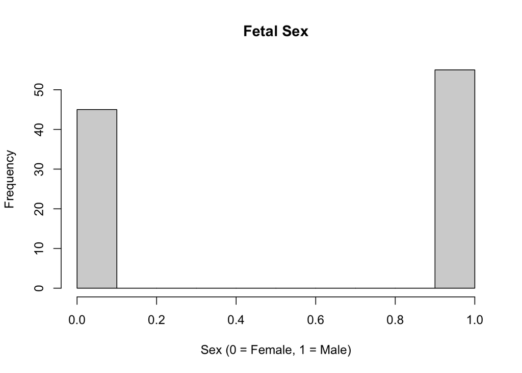

```r
# Fetal sex (0 = female, 1 = male)
fetal_sex <- rbinom(n_samples, size = 1, prob = 0.5)
hist(fetal_sex, main = "Fetal Sex", xlab = "Sex (0 = Female, 1 = Male)")
```

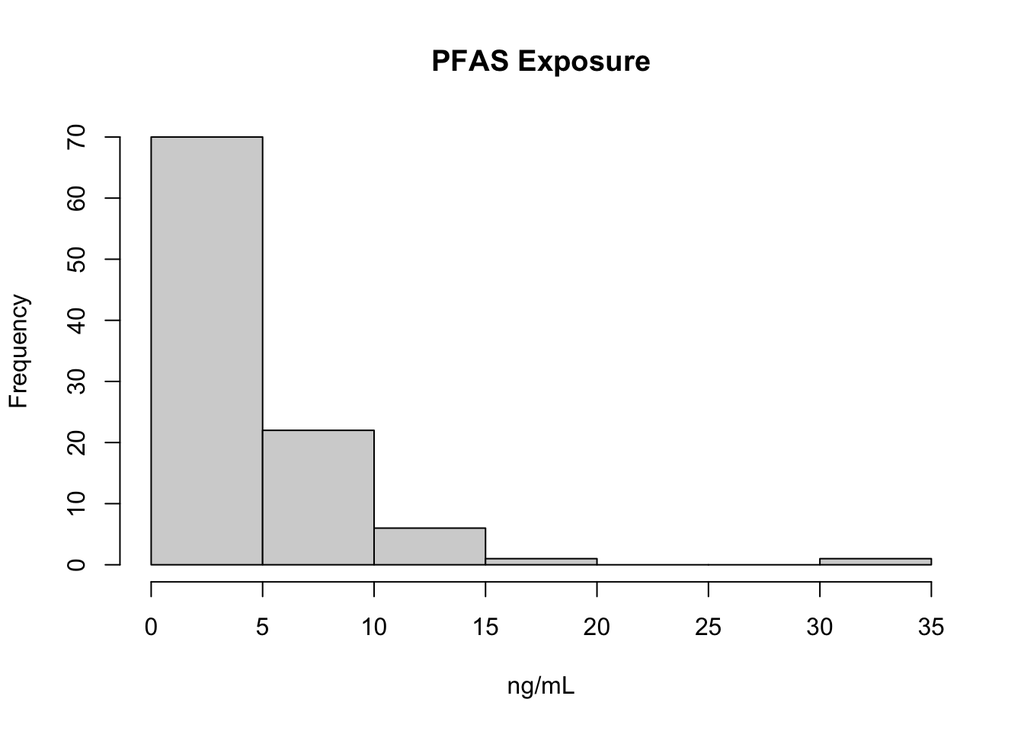

```r
# Maternal PFAS exposure (ng/mL, log-normal)
# Common sdlog values for environmental contaminants in humans can range from 0.8 to 1.5.
PFAS <- rlnorm(n_samples, meanlog = log(3), sdlog = 0.9) # Adjusted sdlog from 0.4 to 0.9
hist(PFAS, main = "PFAS Exposure", xlab = "ng/mL")
```

```r
# Latent confounder U, correlated with PFAS
U <- rnorm(n_samples, mean = scale(PFAS), sd = 1)
```

Next, we simulate maternal DNA methylation data for each isoform, capturing shared environmental or genetic confounding via a latent variable.

## Simulate CpG Methylation from Shared Confounding Signal

```r
n_cpg_per_isoform <- sample(1:5, size = n_isoforms, replace = TRUE)
maternal_meth_list <- lapply(n_cpg_per_isoform, function(n_cpg) {
  matrix(
    plogis(matrix(rnorm(n_samples * n_cpg, mean = rep(U, each = n_cpg), sd = 0.5), nrow = n_samples)), # Adjusted sd from 1 to 0.5
    nrow = n_samples
  )
})
```

## Simulate Isoform-Level Expression Ratios

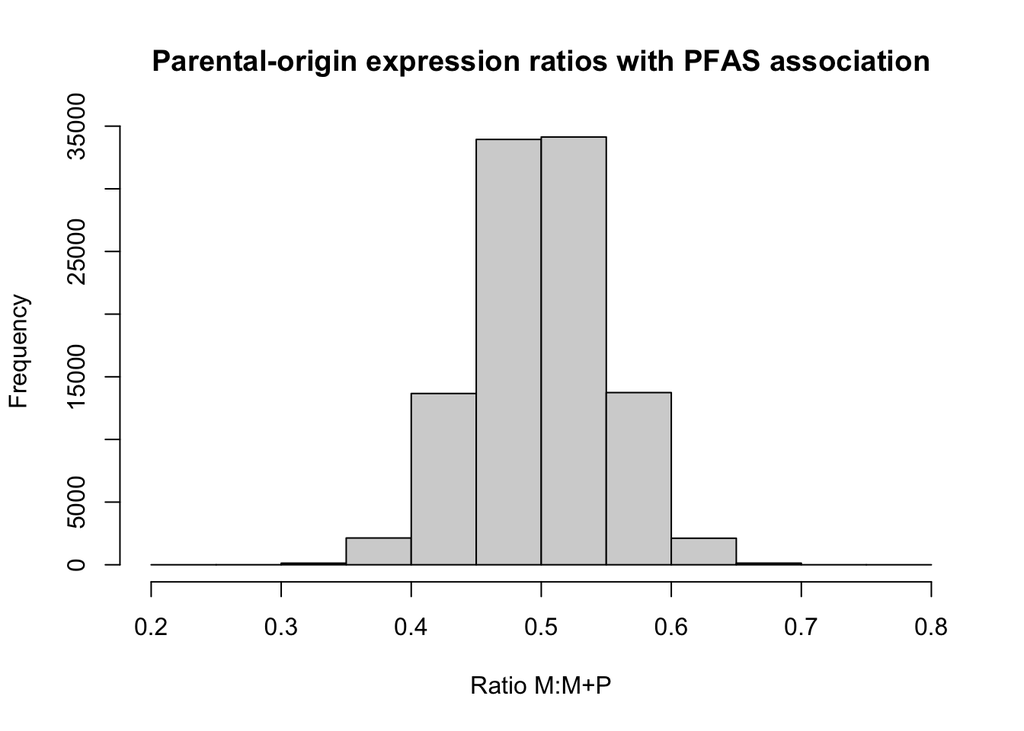

```r
# Start with baseline biallelic expression + noise (maternal expression ratio)
# Using Beta distribution for ratios (bounded 0-1), which is more appropriate for proportions.
# shape1 = 50, shape2 = 50 gives a mean of 0.5 and a reasonable, but not extremely narrow, variance.
expr_ratios <- matrix(rbeta(n_samples * n_isoforms, shape1 = 50, shape2 = 50), nrow = n_samples)

# Define 50% of isoforms as true mediators
mediated_isoforms <- sample(1:n_isoforms, size = n_isoforms * 0.5)

# PFAS influences imprinting in these isoforms
for (i in mediated_isoforms) {
  effect_mean <- 0.05 # Original mean effect
  if (simulation_scenario == "null") {
    effect_mean <- 0 # Set mean effect to 0 for null scenario
  }
  effect <- scale(PFAS) * rnorm(1, mean = effect_mean, sd = 0.01) # Use the adjusted mean
  expr_ratios[, i] <- expr_ratios[, i] + effect

  # Clamp values to ensure they stay within [0,1]
  expr_ratios[, i] <- pmax(0, pmin(1, expr_ratios[, i]))
}

hist(expr_ratios, main = "Parental-origin expression ratios with PFAS association", xlab = "Ratio M:M+P")
```

## Simulate SRS Scores Influenced by Disrupted Imprinting

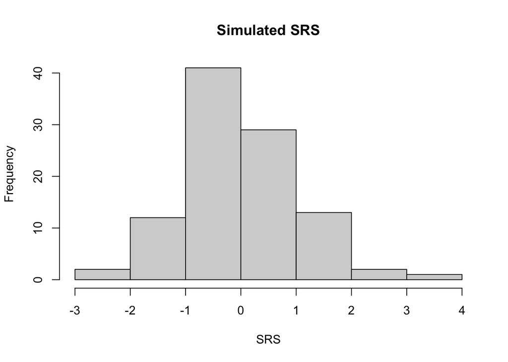

```r
# Create SRS score from expression of mediated isoforms + confounder + noise
srs_effect_mean <- 2 # Original mean effect
if (simulation_scenario == "null") {
  srs_effect_mean <- 0 # Set mean effect to 0 for null scenario
}
SRS_contrib <- rowSums(scale(expr_ratios[, mediated_isoforms]) %*%
                        matrix(rnorm(length(mediated_isoforms), mean = srs_effect_mean, sd = 0.5), ncol = 1)) # Use the adjusted mean
SRS <- scale(SRS_contrib + scale(U) * 0.5 + rnorm(n_samples, 0, 1))

hist(SRS, main = "Simulated SRS", xlab = "SRS")
```

## Include Confounding Effects

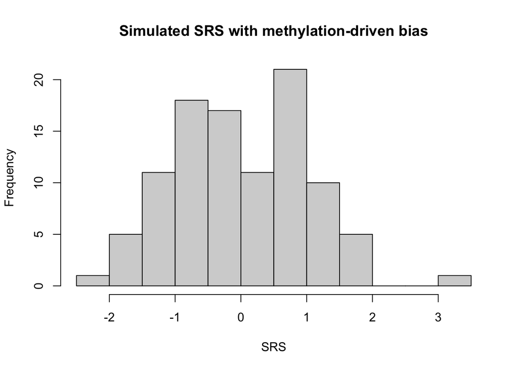

```r
# Select 50% of mediated isoforms to be confounded by methylation
confounded_idx <- sample(mediated_isoforms, size = length(mediated_isoforms) * 0.5)
confounding_contrib <- rep(0, n_samples)

for (i in confounded_idx) {
  meth_mean <- rowMeans(maternal_meth_list[[i]])
  effect_meth_expr <- scale(meth_mean) * rnorm(1, mean = 0.2, sd = 0.05)
  expr_ratios[, i] <- expr_ratios[, i] + effect_meth_expr
  expr_ratios[, i] <- pmax(0, pmin(1, expr_ratios[, i]))

  confounding_contrib <- confounding_contrib + scale(meth_mean) * rnorm(1, mean = 1.5, sd = 0.3)
}

# Inject confounding into SRS
SRS <- scale(SRS + confounding_contrib)
hist(SRS, main = "Simulated SRS with methylation-driven bias", xlab = "SRS")
```

Finally, we clean up and scale the simulated matrices, then reshape the methylation data for downstream analysis and visualization.

## Finalize and Format Output

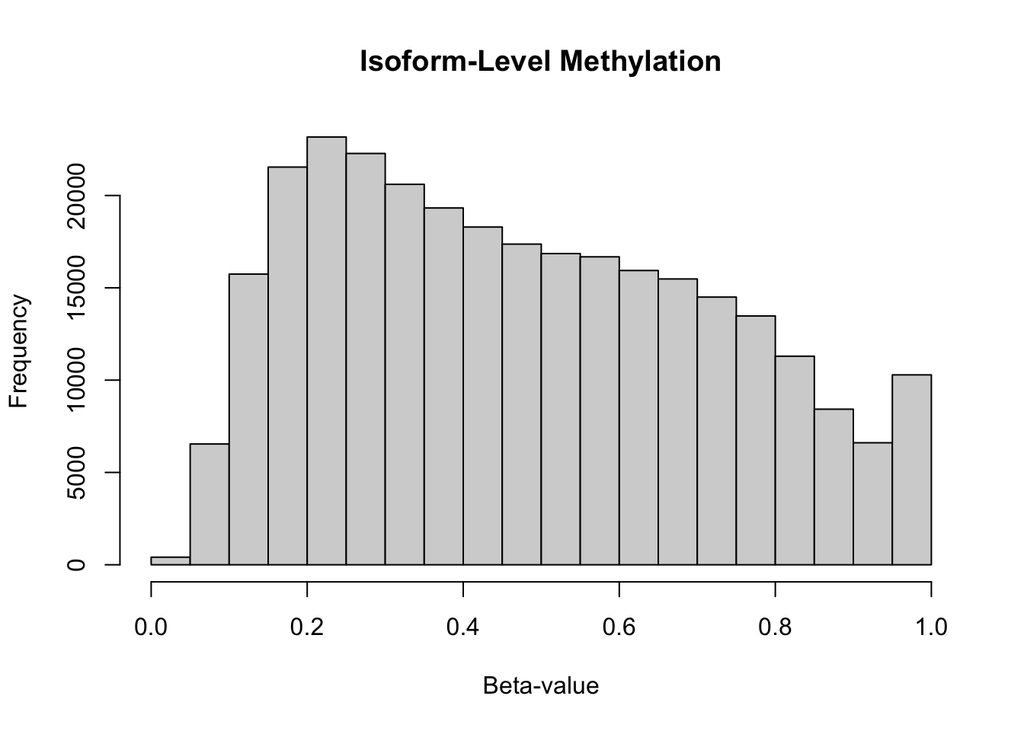

```r
expr_df <- as.data.frame(expr_ratios)
colnames(expr_df) <- paste0("isoform_", 1:n_isoforms)

metadata_df <- data.frame(
  sample = 1:n_samples,
  SRS = SRS,
  PFAS = PFAS,
  fetal_sex = fetal_sex
)

meth_long <- do.call(rbind, lapply(1:n_isoforms, function(i) {
  meth_mat <- maternal_meth_list[[i]]
  n_cpg <- ncol(meth_mat)
  data.frame(
    sample = rep(1:n_samples, times = n_cpg),
    isoform = paste0("isoform_", i),
    cpg = rep(1:n_cpg, each = n_samples),
    meth = as.vector(meth_mat)
  )
}))

hist(meth_long$meth, main = "Isoform-Level Methylation", xlab = "Beta-value")
```

# Moderated Mediation Analysis (lavaan)

Select one isoform for demonstration.

```r
iso <- "isoform_27"
df <- cbind(metadata_df, expr = expr_df[[iso]])

meth_avg <- meth_long %>%
  filter(isoform == iso) %>%
  group_by(sample) %>%
  summarise(m_meth = mean(meth), .groups = "drop")

df <- merge(df, meth_avg, by = "sample")

model <- '
  expr ~ a1*PFAS + a2*fetal_sex + a3*PFAS:fetal_sex
  SRS ~ b1*expr + b2*fetal_sex + b3*expr:fetal_sex + c*PFAS
  ind_female := a1 * b1
  ind_male := (a1 + a3) * (b1 + b3)
  dir := c
  total_female := dir + ind_female
  total_male := dir + ind_male
'

fit <- sem(model, data = df, se = "bootstrap", bootstrap = 100)
summary(fit, standardized = TRUE, fit.measures = TRUE)
```

```
## lavaan 0.6-19 ended normally after 25 iterations
##
##   Estimator                                         ML
##   Optimization method                           NLMINB
##   Number of model parameters                        10
##
##   Number of observations                           100
##
## Model Test User Model:
##
##   Test statistic                               454.346
##   Degrees of freedom                                 5
##   P-value (Chi-square)                           0.000
##
## Model Test Baseline Model:
##
##   Test statistic                               466.844
##   Degrees of freedom                                12
##   P-value                                        0.000
##
## User Model versus Baseline Model:
##
##   Comparative Fit Index (CFI)                    0.012
##   Tucker-Lewis Index (TLI)                      -1.371
##
## Loglikelihood and Information Criteria:
##
##   Loglikelihood user model (H0)                 12.842
##   Loglikelihood unrestricted model (H1)        240.015
##
##   Akaike (AIC)                                  -5.684
##   Bayesian (BIC)                                20.368
##   Sample-size adjusted Bayesian (SABIC)        -11.215
##
## Root Mean Square Error of Approximation:
##
##   RMSEA                                          0.948
##   90 Percent confidence interval - lower         0.875
##   90 Percent confidence interval - upper         1.023
##   P-value H_0: RMSEA <= 0.050                    0.000
```

[output cut: 22 more lines]

```
##     PFAS       (c)    0.061    0.027    2.263    0.024    0.061    0.167
##
## Variances:
##                    Estimate  Std.Err  z-value  P(>|z|)   Std.lv  Std.all
##    .expr              0.003    0.000    8.656    0.000    0.003    0.992
##    .SRS               0.881    0.116    7.583    0.000    0.881    0.363
##     expr:fetal_sex    0.063    0.002   25.512    0.000    0.063    1.000
##
## Defined Parameters:
##                    Estimate  Std.Err  z-value  P(>|z|)   Std.lv  Std.all
##     ind_female       -0.001    0.008   -0.112    0.911   -0.001   -0.002
##     ind_male          0.000    0.008    0.032    0.974    0.000    0.003
##     dir               0.061    0.027    2.252    0.024    0.061    0.167
##     total_female      0.060    0.027    2.194    0.028    0.060    0.164
##     total_male        0.061    0.030    2.020    0.043    0.061    0.169
```

# COCA (Control Outcome Calibration)

```r
# COCA calibration model: includes SRS * fetal_sex interaction
coca_model <- lm(m_meth ~ PFAS + SRS * fetal_sex, data = df)
summary(coca_model)
```

```
##
## Call:
## lm(formula = m_meth ~ PFAS + SRS * fetal_sex, data = df)
##
## Residuals:
##      Min       1Q   Median       3Q      Max
## -0.38796 -0.15127 -0.00607  0.13639  0.40846
##
## Coefficients:
##                Estimate Std. Error t value Pr(>|t|)
## (Intercept)    0.433721   0.034188  12.686  < 2e-16 ***
## PFAS           0.023244   0.004772   4.871 4.42e-06 ***
## SRS            0.084329   0.029457   2.863  0.00517 **
## fetal_sex     -0.062108   0.039773  -1.562  0.12172
## SRS:fetal_sex  0.023191   0.040046   0.579  0.56389
## ---
## Signif. codes:  0 '***' 0.001 '**' 0.01 '*' 0.05 '.' 0.1 ' ' 1
##
## Residual standard error: 0.1941 on 95 degrees of freedom
## Multiple R-squared:  0.4027, Adjusted R-squared:  0.3775
## F-statistic: 16.01 on 4 and 95 DF,  p-value: 4.718e-10
```

```r
# Extract coefficients for calibration formula
beta_A <- coef(coca_model)["PFAS"]
beta_Y <- coef(coca_model)["SRS"]

# Calibrated PFAS effect estimate
psi_coca <- -beta_A / beta_Y
cat("COCA-calibrated PFAS effect estimate:", round(psi_coca, 4), "\n")
```

```
## COCA-calibrated PFAS effect estimate: -0.2756
```

```r
coca_fn <- function(data, indices) {
  d <- data[indices, ]
  fit <- lm(m_meth ~ PFAS + SRS * fetal_sex, data = d)
  -coef(fit)["PFAS"] / coef(fit)["SRS"]
}

boot_out <- boot(df, coca_fn, R = 100)
boot.ci(boot_out, type = "perc")
```

```
## BOOTSTRAP CONFIDENCE INTERVAL CALCULATIONS
## Based on 100 bootstrap replicates
##
## CALL :
## boot.ci(boot.out = boot_out, type = "perc")
##
## Intervals :
## Level     Percentile
## 95%   (-1.2748, -0.1435 )
## Calculations and Intervals on Original Scale
## Some percentile intervals may be unstable
```

# Proximal G-Computation (PGC)

```r
# Stage 1: bridge function includes interaction
bridge_model <- lm(m_meth ~ expr + SRS * fetal_sex, data = df)
df$Z_hat <- predict(bridge_model)

# Stage 2: PFAS * fetal_sex interaction for moderated effect
df$Y_adj <- df$SRS - (df$Z_hat - mean(df$Z_hat))
pgc_model <- lm(Y_adj ~ PFAS * fetal_sex, data = df)
summary(pgc_model)
```

```
##
## Call:
## lm(formula = Y_adj ~ PFAS * fetal_sex, data = df)
##
## Residuals:
##      Min       1Q   Median       3Q      Max
## -1.92692 -0.63075 -0.03451  0.59038  2.51991
##
## Coefficients:
##                Estimate Std. Error t value Pr(>|t|)
## (Intercept)    -0.40099    0.19909  -2.014   0.0468 *
## PFAS            0.06040    0.04344   1.391   0.1676
## fetal_sex       0.31994    0.25255   1.267   0.2083
## PFAS:fetal_sex -0.01015    0.04893  -0.207   0.8361
## ---
## Signif. codes:  0 '***' 0.001 '**' 0.01 '*' 0.05 '.' 0.1 ' ' 1
##
## Residual standard error: 0.8493 on 96 degrees of freedom
## Multiple R-squared:  0.1019, Adjusted R-squared:  0.07386
## F-statistic: 3.632 on 3 and 96 DF,  p-value: 0.01565
```

```r
pgc_fn <- function(data, indices) {
  d <- data[indices, ]

  # Stage 1: bridge model with SRS * sex
  bridge <- lm(m_meth ~ expr + SRS * fetal_sex, data = d)
  Z_hat <- predict(bridge)
  Y_adj <- d$SRS - (Z_hat - mean(Z_hat))

  # Stage 2: PGC with PFAS * fetal_sex
  pgc_fit <- lm(Y_adj ~ PFAS * fetal_sex, data = cbind(d, Y_adj))

  # Return main effect of PFAS (for females) only
  return(coef(pgc_fit)["PFAS"])
}

pgc_est_female <- coef(pgc_model)["PFAS"]
pgc_est_male <- coef(pgc_model)["PFAS"] + coef(pgc_model)["PFAS:fetal_sex"]

pgc_fn <- function(data, indices) {
  d <- data[indices, ]
  bridge <- lm(m_meth ~ expr + SRS * fetal_sex, data = d)
  Z_hat <- predict(bridge)
  Y_adj <- d$SRS - (Z_hat - mean(Z_hat))
  pgc_fit <- lm(Y_adj ~ PFAS * fetal_sex, data = cbind(d, Y_adj))

  beta_pfas <- coef(pgc_fit)["PFAS"]
  beta_int <- coef(pgc_fit)["PFAS:fetal_sex"]
  c(female = beta_pfas, male = beta_pfas + beta_int)
}

# Bootstrap
boot_out <- boot(df, pgc_fn, R = 100)
boot.ci(boot_out, type = "perc")
```

```
## BOOTSTRAP CONFIDENCE INTERVAL CALCULATIONS
## Based on 100 bootstrap replicates
##
## CALL :
## boot.ci(boot.out = boot_out, type = "perc")
##
## Intervals :
## Level     Percentile
## 95%   (-0.0343,  0.1289 )
## Calculations and Intervals on Original Scale
## Some percentile intervals may be unstable
```

# Parallelized Analysis Across Isoforms

```r
# Bootstraps
n_boot <- 100

# Set up parallel backend
n_cores <- parallel::detectCores() - 1
cl <- makeCluster(n_cores)
registerDoParallel(cl)

# Predefine names for output list
isoform_names <- paste0("isoform_", 1:n_isoforms)

# Parallel processing
results_list <- foreach(i = 1:n_isoforms, .packages = c("dplyr", "lavaan", "boot")) %dopar% {
  iso_name <- isoform_names[i]

  df <- cbind(metadata_df, expr = expr_df[[iso_name]])

  meth_avg <- meth_long %>%
    filter(isoform == iso_name) %>%
    group_by(sample) %>%
    summarise(m_meth = mean(meth), .groups = "drop")

  df <- merge(df, meth_avg, by = "sample")

  # Lavaan model
  model <- '
    expr ~ a1*PFAS + a2*fetal_sex + a3*PFAS:fetal_sex
    SRS ~ b1*expr + b2*fetal_sex + b3*expr:fetal_sex + c*PFAS
    ind_female := a1 * b1
    ind_male := (a1 + a3) * (b1 + b3)
    dir := c
    total_female := dir + ind_female
    total_male := dir + ind_male
  '

  lavaan_fit <- tryCatch({
    sem(model, data = df, se = "bootstrap", bootstrap = n_boot)
  }, error = function(e) NULL)

  # COCA
  coca_model <- lm(m_meth ~ PFAS + SRS * fetal_sex, data = df)
  beta_A <- coef(coca_model)["PFAS"]
  beta_Y <- coef(coca_model)["SRS"]
  psi_coca <- -beta_A / beta_Y

  coca_fn <- function(data, indices) {
    d <- data[indices, ]
    fit <- lm(m_meth ~ PFAS + SRS * fetal_sex, data = d)
    -coef(fit)["PFAS"] / coef(fit)["SRS"]
  }

  coca_boot <- boot(df, coca_fn, R = n_boot)
  coca_ci <- tryCatch(boot.ci(coca_boot, type = "perc"), error = function(e) NULL)

  # PGC
  bridge_model <- lm(m_meth ~ expr + SRS * fetal_sex, data = df)
  df$Z_hat <- predict(bridge_model)
  df$Y_adj <- df$SRS - (df$Z_hat - mean(df$Z_hat))

  pgc_model <- lm(Y_adj ~ PFAS * fetal_sex, data = df)

  pgc_fn <- function(data, indices) {
    d <- data[indices, ]
    bridge <- lm(m_meth ~ expr + SRS * fetal_sex, data = d)
    Z_hat <- predict(bridge)
    Y_adj <- d$SRS - (Z_hat - mean(Z_hat))
    pgc_fit <- lm(Y_adj ~ PFAS * fetal_sex, data = cbind(d, Y_adj))
    coef(pgc_fit)["PFAS"]
  }

  pgc_boot <- boot(df, pgc_fn, R = n_boot)
  pgc_ci <- tryCatch(boot.ci(pgc_boot, type = "perc"), error = function(e) NULL)

  # Return result for this isoform
  list(
    lavaan_fit = lavaan_fit,
    COCA = list(
      model = coca_model,
      boot = coca_boot,
      ci = coca_ci
    ),
    PGC = list(
      model = pgc_model,
      boot = pgc_boot,
      ci = pgc_ci
    )
  )
}

# Set names to match isoform identifiers
names(results_list) <- isoform_names

# Stop cluster
stopCluster(cl)

# Save results to file
save(list=c("results_list"),file="results_list.RData")
```

# Plotting

```r
# Initialize results data.frames
sem_pval_df <- data.frame()
coca_df <- data.frame()
pgc_df <- data.frame()

iso_names <- names(results_list)

for (i in seq_along(results_list)) {
  iso <- iso_names[i]
  res <- results_list[[i]]

  # --- SEM path p-values
  fit <- res$lavaan_fit
  if (!is.null(fit)) {
    pe <- tryCatch(parameterEstimates(fit), error = function(e) NULL)
    if (!is.null(pe)) {
      selected_paths <- pe %>%
        filter(label %in% c("a1", "a3", "b1", "b3", "c",
                            "ind_female", "ind_male", "total_female", "total_male")) %>%
        select(label, pvalue)
      if (nrow(selected_paths) > 0) {
        sem_pval_df <- bind_rows(sem_pval_df,
                                 data.frame(
                                   isoform = iso,
                                   path = selected_paths$label,
                                   pval = selected_paths$pvalue
                                 ))
      }
    }
  }

  # --- COCA model: extract PFAS, fetal_sex, and interaction p-values and CI
  coca_fit <- results_list[[i]][["COCA"]][["model"]]

  if (!is.null(coca_fit)) {
    coef_table <- coef(summary(coca_fit))
    confint_table <- tryCatch(confint(coca_fit), error = function(e) NULL)

    pval_pfas  <- coef_table["PFAS", "Pr(>|t|)"]
    pval_sex   <- if ("fetal_sex" %in% rownames(coef_table)) coef_table["fetal_sex", "Pr(>|t|)"] else NA
    pval_int   <- if ("SRS:fetal_sex" %in% rownames(coef_table)) coef_table["SRS:fetal_sex", "Pr(>|t|)"] else NA

    ci_lower <- ci_upper <- NA
    if (!is.null(confint_table) && "PFAS" %in% rownames(confint_table)) {
      ci_lower <- confint_table["PFAS", 1]
      ci_upper <- confint_table["PFAS", 2]
    }

    signif <- !(is.na(ci_lower) || (ci_lower < 0 & ci_upper > 0))  # TRUE if CI excludes 0

    coca_df <- bind_rows(coca_df, data.frame(
      isoform = iso,
      pval_PFAS = pval_pfas,
      pval_fetal_sex = pval_sex,
      pval_PFAS_fetal_sex = pval_int,
      ci_lower = ci_lower,
      ci_upper = ci_upper,
      significant = signif
    ))
  }

  # --- PGC model: extract PFAS, fetal_sex, and interaction p-values
  pgc_model <- tryCatch(res$PGC$model, error = function(e) NULL)
  pgc_boot  <- tryCatch(res$PGC$boot, error = function(e) NULL)

  if (!is.null(pgc_model) && !is.null(pgc_boot)) {
    coef_pg <- coef(summary(pgc_model))

    pval_pfas <- coef_pg["PFAS", "Pr(>|t|)"]
    pval_sex  <- if ("fetal_sex" %in% rownames(coef_pg)) coef_pg["fetal_sex", "Pr(>|t|)"] else NA
    pval_int  <- if ("PFAS:fetal_sex" %in% rownames(coef_pg)) coef_pg["PFAS:fetal_sex", "Pr(>|t|)"] else NA

    boot_estimates <- pgc_boot$t
    signif <- NA
    ci_lower <- ci_upper <- NA
    if (!is.null(boot_estimates) && length(boot_estimates) > 1) {
      ci_bounds <- quantile(boot_estimates, probs = c(0.025, 0.975), na.rm = TRUE)
      ci_lower <- ci_bounds[1]
      ci_upper <- ci_bounds[2]
      signif <- !(ci_lower < 0 & ci_upper > 0)
    }

    pgc_df <- bind_rows(pgc_df, data.frame(
      isoform = iso,
      pval_PFAS = pval_pfas,
      pval_fetal_sex = pval_sex,
      pval_PFAS_fetal_sex = pval_int,
      ci_lower = ci_lower,
      ci_upper = ci_upper,
      significant = signif
    ))
  }
}
```

## SEM p-value distributions

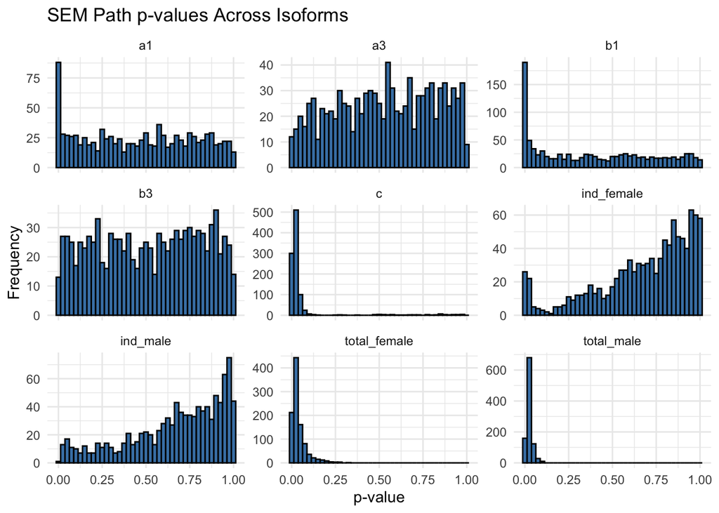

Interpretation of SEM Path p-value Distributions

| Path | Pattern | Interpretation |
| --- | --- | --- |
| a1 | Left skew with peak near 0 | PFAS is robustly associated with imprinting disruption across many isoforms. |
| a3 | Roughly uniform | Fetal sex moderates the PFAS-expression path only in some isoforms; no strong overall signal. |
| b1 | Strong left skew with high peak at 0 | Imprinting disruption is strongly associated with SRS across isoforms. |
| b3 | Roughly uniform | No consistent interaction between sex and expression on SRS. |
| c | Left skew (many < 0.05) | PFAS has a direct effect on SRS in many isoforms. |
| ind_female | Right skew (most p > 0.5) | Female-specific indirect effects are weak or absent across most isoforms. |
| ind_male | Right skew (most p > 0.5) | Male-specific mediation effects are weak or absent across most isoforms. |
| total_female | Extreme left skew (strong signal) | PFAS has strong total effects on SRS in females for many isoforms. |
| total_male | Extreme left skew (strong signal) | PFAS has strong total effects on SRS in males for many isoforms. |

```r
ggplot(sem_pval_df, aes(x = pval)) +
  geom_histogram(binwidth = 0.025, fill = "#4682B4", color = "black") +
  facet_wrap(~ path, scales = "free_y") +
  theme_minimal() +
  labs(title = "SEM Path p-values Across Isoforms",
       x = "p-value", y = "Frequency")
```

## COCA & PGC p-value distributions

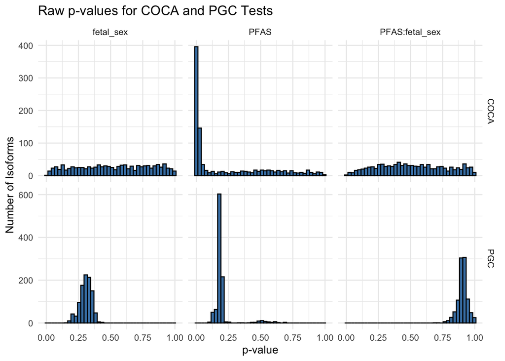

```r
library(dplyr)
library(tidyr)
library(ggplot2)

# Pivot COCA to long format
coca_pvals_long <- coca_df %>%
  pivot_longer(
    cols = c(pval_PFAS, pval_fetal_sex, pval_PFAS_fetal_sex),
    names_to = "Term",
    values_to = "pval"
  ) %>%
  mutate(
    Method = "COCA",
    Term = recode(Term,
                  "pval_PFAS" = "PFAS",
                  "pval_fetal_sex" = "fetal_sex",
                  "pval_PFAS_fetal_sex" = "PFAS:fetal_sex")
  )

# Pivot PGC to long format
pgc_pvals_long <- pgc_df %>%
  pivot_longer(
    cols = c(pval_PFAS, pval_fetal_sex, pval_PFAS_fetal_sex),
    names_to = "Term",
    values_to = "pval"
  ) %>%
  mutate(
    Method = "PGC",
    Term = recode(Term,
                  "pval_PFAS" = "PFAS",
                  "pval_fetal_sex" = "fetal_sex",
                  "pval_PFAS_fetal_sex" = "PFAS:fetal_sex")
  )

# Combine and filter non-missing p-values
pval_df <- bind_rows(coca_pvals_long, pgc_pvals_long) %>%
  filter(!is.na(pval))

# Plot
ggplot(pval_df, aes(x = pval)) +
  geom_histogram(bins = 40, fill = "steelblue", color = "black") +
  facet_grid(Method ~ Term, scales = "free", drop = TRUE) +
  theme_minimal() +
  labs(
    title = "Raw p-values for COCA and PGC Tests",
    x = "p-value", y = "Number of Isoforms"
  )
```

## COCA & PGC significance

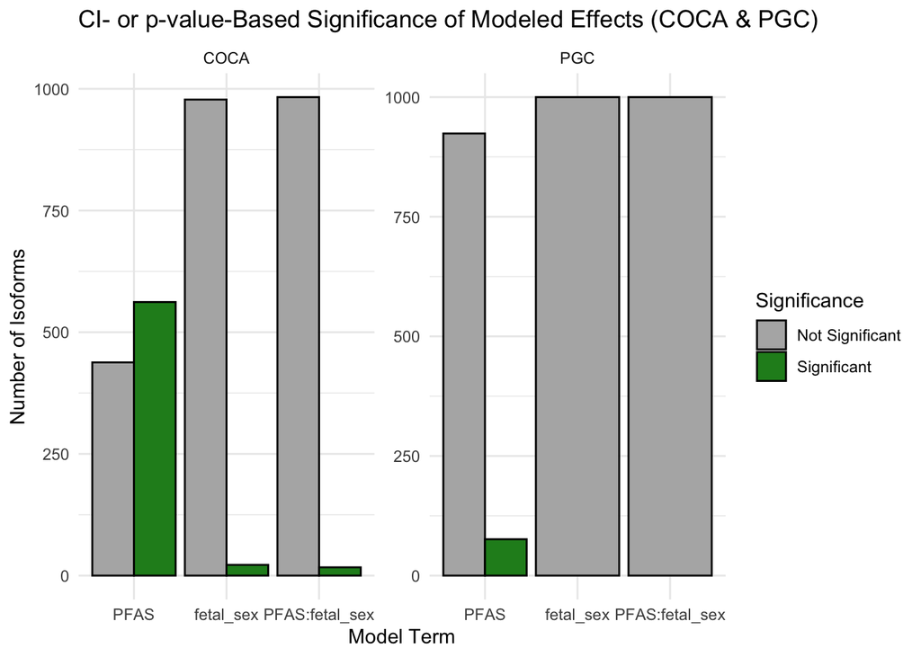

Summary of COCA and PGC Results for Isoform-Level Mediation with Sex Interaction

[output not shown]

```r
# Significance for PFAS (from 95% CI exclusion flag)
sig_pfas <- bind_rows(
  coca_df %>% transmute(isoform, significant, Method = "COCA", Term = "PFAS"),
  pgc_df %>% transmute(isoform, significant, Method = "PGC", Term = "PFAS")
)

# Significance for fetal_sex (p < 0.05)
sig_sex <- bind_rows(
  coca_df %>%
    filter(!is.na(pval_fetal_sex)) %>%
    mutate(significant = pval_fetal_sex < 0.05,
           Method = "COCA", Term = "fetal_sex") %>%
    select(isoform, significant, Method, Term),
  pgc_df %>%
    filter(!is.na(pval_fetal_sex)) %>%
    mutate(significant = pval_fetal_sex < 0.05,
           Method = "PGC", Term = "fetal_sex") %>%
    select(isoform, significant, Method, Term)
)

# Significance for PFAS:fetal_sex interaction (p < 0.05)
sig_int <- bind_rows(
  coca_df %>%
    filter(!is.na(pval_PFAS_fetal_sex)) %>%
    mutate(significant = pval_PFAS_fetal_sex < 0.05,
           Method = "COCA", Term = "PFAS:fetal_sex") %>%
    select(isoform, significant, Method, Term),
  pgc_df %>%
    filter(!is.na(pval_PFAS_fetal_sex)) %>%
    mutate(significant = pval_PFAS_fetal_sex < 0.05,
           Method = "PGC", Term = "PFAS:fetal_sex") %>%
    select(isoform, significant, Method, Term)
)

# Combine all
sig_df <- bind_rows(sig_pfas, sig_sex, sig_int) %>%
  mutate(
    Significance = ifelse(significant, "Significant", "Not Significant"),
    Method = factor(Method),
    Term = factor(Term, levels = c("PFAS", "fetal_sex", "PFAS:fetal_sex")),
    Significance = factor(Significance)
  )

# Plot
ggplot(sig_df, aes(x = Term, fill = Significance)) +
  geom_bar(position = "dodge", color = "black", na.rm = TRUE) +
  facet_wrap(~ Method, drop = TRUE, scales = "free") +
  scale_fill_manual(values = c("gray70", "forestgreen")) +
  theme_minimal() +
  labs(
    title = "CI- or p-value-Based Significance of Modeled Effects (COCA & PGC)",
    x = "Model Term", y = "Number of Isoforms", fill = "Significance"
  )
```

# Regression adjustment models with control outcome variable as covariate

```r
# Example for one isoform
iso_idx <- 27
meth_proxy <- rowMeans(maternal_meth_list[[iso_idx]])

# Include sex main effect and interaction with expression
model <- lm(SRS ~ PFAS + expr_ratios[, iso_idx] * fetal_sex + meth_proxy)

summary(model)
```

```
##
## Call:
## lm(formula = SRS ~ PFAS + expr_ratios[, iso_idx] * fetal_sex +
##     meth_proxy)
##
## Residuals:
##      Min       1Q   Median       3Q      Max
## -1.84241 -0.60557 -0.06971  0.48067  2.01215
##
## Coefficients:
##                                   Estimate Std. Error t value Pr(>|t|)
## (Intercept)                      -1.767593   1.292327  -1.368    0.175
## PFAS                             -0.001773   0.023715  -0.075    0.941
## expr_ratios[, iso_idx]            1.094369   2.545771   0.430    0.668
## fetal_sex                        -1.364725   1.644861  -0.830    0.409
## meth_proxy                        2.100208   0.416820   5.039 2.26e-06 ***
## expr_ratios[, iso_idx]:fetal_sex  3.405474   3.302221   1.031    0.305
## ---
## Signif. codes:  0 '***' 0.001 '**' 0.01 '*' 0.05 '.' 0.1 ' ' 1
##
## Residual standard error: 0.8589 on 94 degrees of freedom
## Multiple R-squared:  0.2996, Adjusted R-squared:  0.2623
## F-statistic: 8.041 on 5 and 94 DF,  p-value: 2.398e-06
```

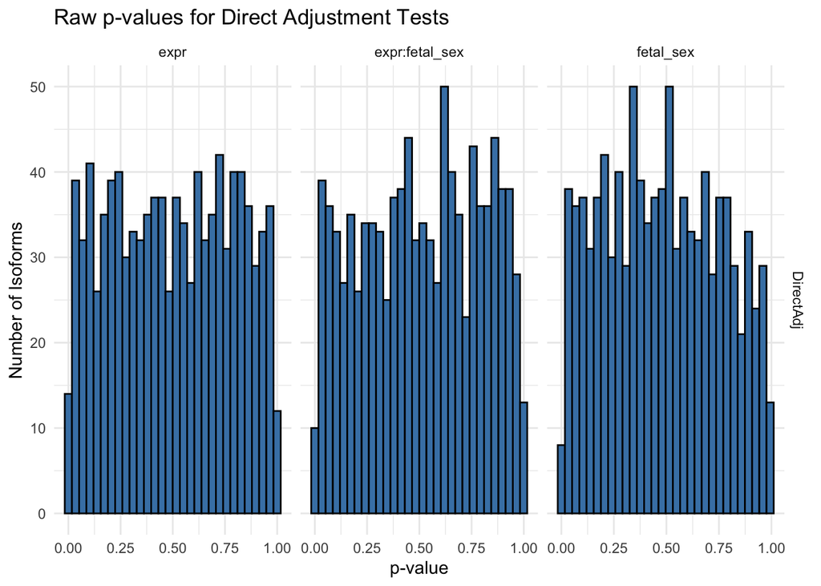

```r
# Initialize results table for moderated direct adjustment
adjusted_lm_results <- data.frame(
  isoform = 1:n_isoforms,
  coef_expr = NA,           p_expr = NA,           sig_ci_expr = NA,
  coef_sex = NA,            p_sex = NA,            sig_ci_sex = NA,
  coef_interaction = NA,    p_interaction = NA,    sig_ci_interaction = NA
)

for (i in 1:n_isoforms) {
  meth_proxy <- rowMeans(maternal_meth_list[[i]])
  fit <- lm(SRS ~ PFAS + expr_ratios[, i] * fetal_sex + meth_proxy)
  confint_fit <- confint(fit)
  coef_names <- names(coef(fit))

  expr_term <- "expr_ratios[, i]"
  sex_term  <- "fetal_sex"
  int_term  <- "expr_ratios[, i]:fetal_sex"

  # Expression term
  if (expr_term %in% coef_names) {
    idx <- which(coef_names == expr_term)
    adjusted_lm_results$coef_expr[i] <- coef(fit)[idx]
    adjusted_lm_results$p_expr[i] <- summary(fit)$coefficients[idx, "Pr(>|t|)"]
    adjusted_lm_results$sig_ci_expr[i] <- !(0 >= confint_fit[idx, 1] & 0 <= confint_fit[idx, 2])
  }

  # Fetal sex term
  if (sex_term %in% coef_names) {
    idx <- which(coef_names == sex_term)
    adjusted_lm_results$coef_sex[i] <- coef(fit)[idx]
    adjusted_lm_results$p_sex[i] <- summary(fit)$coefficients[idx, "Pr(>|t|)"]
    adjusted_lm_results$sig_ci_sex[i] <- !(0 >= confint_fit[idx, 1] & 0 <= confint_fit[idx, 2])
  }

  # Interaction term
  if (int_term %in% coef_names) {
    idx <- which(coef_names == int_term)
    adjusted_lm_results$coef_interaction[i] <- coef(fit)[idx]
    adjusted_lm_results$p_interaction[i] <- summary(fit)$coefficients[idx, "Pr(>|t|)"]
    adjusted_lm_results$sig_ci_interaction[i] <- !(0 >= confint_fit[idx, 1] & 0 <= confint_fit[idx, 2])
  }
}

# Stack into long format for p-values
pval_df <- bind_rows(
  adjusted_lm_results %>% select(isoform, pval = p_expr) %>% mutate(Term = "expr"),
  adjusted_lm_results %>% select(isoform, pval = p_sex) %>% mutate(Term = "fetal_sex"),
  adjusted_lm_results %>% select(isoform, pval = p_interaction) %>% mutate(Term = "expr:fetal_sex")
)

# Add method label
pval_df$Method <- "DirectAdj"

ggplot(pval_df, aes(x = pval)) +
  geom_histogram(bins = 30, fill = "steelblue", color = "black") +
  facet_grid(Method ~ Term, scales = "free", drop = TRUE) +
  theme_minimal() +
  labs(
    title = "Raw p-values for Direct Adjustment Tests",
    x = "p-value", y = "Number of Isoforms"
  )
```

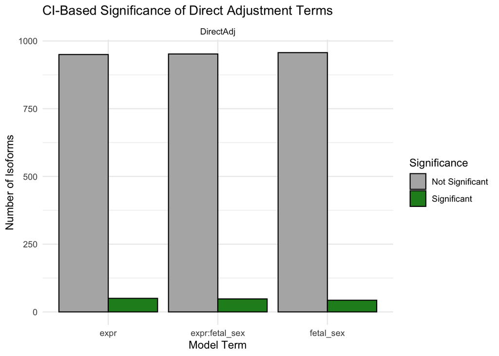

Summary of Direct Adjustment Results (Huang, 2021 Approach)

[output not shown]

```r
sig_df <- bind_rows(
  adjusted_lm_results %>% transmute(isoform, Term = "expr",         sig = sig_ci_expr),
  adjusted_lm_results %>% transmute(isoform, Term = "fetal_sex",    sig = sig_ci_sex),
  adjusted_lm_results %>% transmute(isoform, Term = "expr:fetal_sex", sig = sig_ci_interaction)
) %>%
  mutate(
    Method = "DirectAdj",
    Significance = ifelse(sig, "Significant", "Not Significant")
  )

ggplot(sig_df, aes(x = Term, fill = Significance)) +
  geom_bar(position = "dodge", color = "black") +
  facet_wrap(~ Method) +
  scale_fill_manual(values = c("gray70","forestgreen")) +
  theme_minimal() +
  labs(
    title = "CI-Based Significance of Direct Adjustment Terms",
    x = "Model Term", y = "Number of Isoforms", fill = "Significance"
  )
```

# Calculate Type I Error Rates

```r
# For a null simulation, we expect these rates to be close to a = 0.05
# for true null effects, indicating correct Type I error control.
# Rates significantly above 0.05 suggest inflated Type I error.

type1_error_results <- list()

# 1. SEM Type I Error
# Focusing on the mediation paths (a1, b1) and indirect effects (ind_female, ind_male)
# which are set to null in the simulation scenario.
sem_type1 <- sem_pval_df %>%
  filter(path %in% c("a1", "b1", "ind_female", "ind_male")) %>%
  group_by(path) %>%
  summarise(
    Type1_Error_Rate = mean(pval < 0.05, na.rm = TRUE),
    .groups = "drop"
  )
type1_error_results$SEM <- sem_type1

# 2. COCA Type I Error
# For COCA, 'significant' is determined by whether the 95% CI for the PFAS effect excludes 0.
# For other terms (fetal_sex, SRS:fetal_sex interaction), we use a p-value threshold.
coca_type1 <- coca_df %>%
  summarise(
    Type1_Error_Rate_PFAS = mean(significant, na.rm = TRUE), # Uses the 'significant' flag from CI
    Type1_Error_Rate_fetal_sex = mean(pval_fetal_sex < 0.05, na.rm = TRUE),
    Type1_Error_Rate_SRS_fetal_sex_int = mean(pval_PFAS_fetal_sex < 0.05, na.rm = TRUE) # This is for the SRS:fetal_sex interaction in the COCA model
  ) %>%
  pivot_longer(everything(), names_to = "path", values_to = "Type1_Error_Rate") %>%
  mutate(path = gsub("Type1_Error_Rate_", "", path))
type1_error_results$COCA <- coca_type1

# 3. PGC Type I Error
# For PGC, 'significant' for PFAS is also based on CI exclusion of 0.
# For other terms (fetal_sex, PFAS:fetal_sex interaction), p-value threshold is used.
pgc_type1 <- pgc_df %>%
  summarise(
    Type1_Error_Rate_PFAS = mean(significant, na.rm = TRUE), # Uses the 'significant' flag from CI
    Type1_Error_Rate_fetal_sex = mean(pval_fetal_sex < 0.05, na.rm = TRUE),
    Type1_Error_Rate_PFAS_fetal_sex_int = mean(pval_PFAS_fetal_sex < 0.05, na.rm = TRUE) # This is for the PFAS:fetal_sex interaction in the PGC model
  ) %>%
  pivot_longer(everything(), names_to = "path", values_to = "Type1_Error_Rate") %>%
  mutate(path = gsub("Type1_Error_Rate_", "", path))
type1_error_results$PGC <- pgc_type1

# 4. Regression Adjustment Type I Error
# 'sig_ci_*' flags are based on CI excluding 0.
adj_type1 <- adjusted_lm_results %>%
  summarise(
    Type1_Error_Rate_expr = mean(sig_ci_expr, na.rm = TRUE),
    Type1_Error_Rate_sex = mean(sig_ci_sex, na.rm = TRUE),
    Type1_Error_Rate_expr_fetal_sex_int = mean(sig_ci_interaction, na.rm = TRUE) # This is for the expr:fetal_sex interaction in the direct adjustment model
  ) %>%
  pivot_longer(everything(), names_to = "path", values_to = "Type1_Error_Rate") %>%
  mutate(path = gsub("Type1_Error_Rate_", "", path))
type1_error_results$DirectAdj <- adj_type1
```

Type I Error Rates Across Different Methods and Causal Paths (Null Simulation)

| Method | path | Type1_Error_Rate |
| --- | --- | --- |
| SEM | PFAS -> Expression (a1) | 0.127 |
| SEM | Expression -> SRS (b1) | 0.259 |
| SEM | Indirect Effect (Female) | 0.051 |
| SEM | Indirect Effect (Male) | 0.022 |
| COCA | PFAS Main Effect | 0.562 |
| COCA | Fetal Sex Main Effect | 0.022 |
| COCA | SRS:Fetal Sex Interaction | 0.017 |
| PGC | PFAS Main Effect | 0.076 |
| PGC | Fetal Sex Main Effect | 0.000 |
| PGC | PFAS:Fetal Sex Interaction | 0.000 |
| Direct Adjustment | Expression Main Effect | 0.050 |
| Direct Adjustment | Sex Main Effect | 0.043 |
| Direct Adjustment | Expression:Fetal Sex Interaction | 0.048 |

#### Interpretation of Overall Type 1 Error Rates by Method

##### COCA

COCA yields a highly inflated Type I error for the PFAS main effect (0.562), indicating substantial bias even under null simulation. This reinforces concerns that COCA’s calibration may fail when residual confounding (e.g., via methylation) is strong and unmeasured. However, the fetal sex and interaction terms remain well controlled (0.022 and 0.017, respectively), confirming that the inflation is specific to the PFAS term, likely due to uncorrected bias in the PFAS -> methylation -> SRS pathway. This highlights COCA’s vulnerability to latent confounders, especially when the primary exposure is entangled with the mediator’s confounders.

##### PGC

PGC produces moderate inflation for the PFAS effect (0.076), but maintains perfect control for the fetal sex and interaction terms (both 0.000). This suggests that PGC partially mitigates PFAS-related confounding via proxy variables (expression), but not completely — especially when the proxy does not fully capture the true exposure–mediator relationship. While more conservative than COCA, PGC still exhibits nontrivial false positive rates and may require stronger or better-calibrated proxies to perform reliably under the null.

##### Direct Adjustment

The direct adjustment method (SRS ~ expression + sex + interaction) shows excellent Type I error control across all tested paths.